# Optimización de memoria

Noviembre, 2015

## Introducción

Una analista de datos se preocupa día a día por la velocidad de ejecución de sus códigos.

[figure not shown]

Podría trabajar con volúmenes de información cada vez más grandes y realizar tareas ambiciosas siempre y cuando su código se ejecute de manera rápida.

## Optimización de memoria

Un sólido conocimiento sobre la administración de memoria en R, nos ayudará a predecir cuanta memoria necesitamos para realizar una cierta tarea asignada.

### Prerequisitos

```r
install.packages('ggplot2', dependencies = TRUE)
install.packages('pryr', dependencies = TRUE)
devtools::install_github('hadley/lineprof')
```

## Tamaño de un objeto

La función `pryr::object_size()` calcula el número de bytes en memoria que ocupa un determinado objeto.

```r
object_size(1:20)
```

```
#> 168 B
```

```r
object_size(mean)
```

```
#> 832 B
```

```r
object_size(mtcars)
```

```
#> 6.74 kB
```

## Tamaño de un objeto

Analicemos el número de bytes que ocupa un vector a medida que su longitud incrementa. Esperaríamos que el espacio en memoria para un vector incremente proporcionalmente a su longitud, sin embargo esto no sucede.

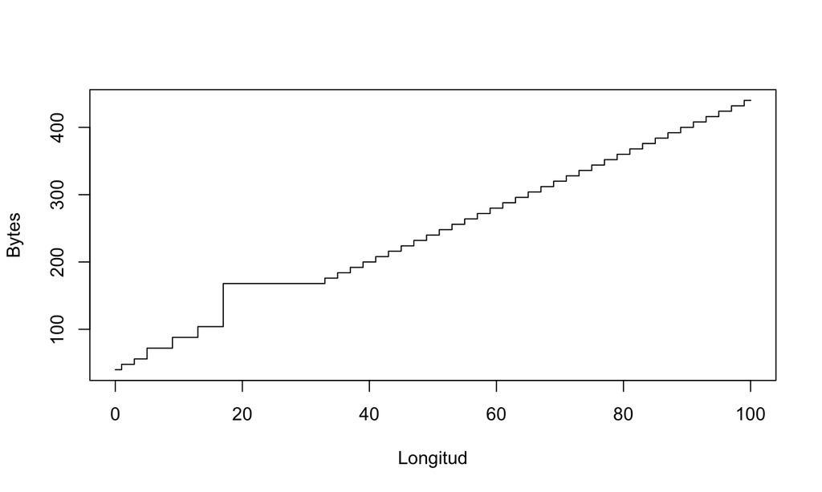

```r
sizes <- sapply(0:100, function(n) object_size(seq_len(n)))
plot(0:100, sizes, xlab='Longitud', ylab='Bytes', type='s')
```

## Tamaño de un vector

Cualquier vector de longitud 0 ocupa aproximadamente 40 bytes de memoria.

```r
object_size(numeric())
```

```
#> 40 B
```

```r
object_size(logical())
```

```
#> 40 B
```

```r
object_size(list())
```

```
#> 40 B
```

Las versiones anteriores a `R3.0.0` soportaban vectores de longitud máxima \(2^{31}\) elementos (aproximadamente 2 billones de elementos), las versiones posteriores soportan vectores de longitud \(2^{52}\).

## Componentes compartidas

Una sutileza del tamaño de un objeto es que sus componentes pueden ser compartidas a múltiples objetos.

```r
x <- 1:1e6
object_size(x)
```

```
#> 4 MB
```

```r
y <- list(x,x,x)
object_size(y)
```

```
#> 4 MB
```

## Memoria utilizada

La función `pryr::mem_used()` muestra el total de bytes que ocupan todos los objetos en memoria.

```r
mem_used()
```

```
#> 32.1 MB
```

La función `mem_change()` muestra los cambios en el espacio de memoria durante la ejecución del código.

```r
mem_change(x <- 1:1e6)
```

```
#> 4.01 MB
```

```r
mem_change(rm(x))
```

```
#> -4 MB
```

## Integrando R con C++

Algunas veces el código de R no es demasiado rápido, si a eso le sumamos que muchos usuarios programan de manera muy *pobre* obtenemos un lenguaje lento.

[figure not shown]

En esta parte aprenderemos a reescribir funciones en C++, de manera que el código se vuelva más rápido al momento de trabajar sobre grandes cantidades de datos.

## Mi primera función de C++

La función `cppFunction()` permite escribir funciones de C++ en R.

```r
cppFunction('int add (int x, int y, int z){
            int sum=x+y+z;
            return sum;
            }')
```

Cuando ejecutamos el código, Rcpp compila el código de C++ y construye una función de R que se conecta a la función compilada de C++.

## Integrando R con SQL

SQL es un lenguaje declarativo de acceso a bases de datos relacionales que permiten especificar diversos tipos de operaciones en ellas.

Una de las características principales del lenguaje es permitir efectuar consultas con el fin de recuperar, de forma sencilla, información de bases de datos, así como hacer cambios en ellas.

[figure not shown]

SQL es un lenguaje de acceso a bases de datos que explota la flexibilidad y potencia de los sistemas relacionales y permite así gran variedad de operaciones.

## Manipulación de datos

Un lenguaje de manipulación de datos permite al usuario llevar a cabo las tareas de consulta o tratamiento de datos, organizados por el modelo de datos adecuado.

```r
install.packages('sqldf', dependencies = TRUE)
library(sqldf)
```

### Sentencias

- **SELECT**
- **FROM**
- **WHERE**
- **GROUP BY**
- **HAVING**
- **ORDER BY**

## Preguntas